# Loading and preprocessing the data

```r
knitr::opts_chunk$set(echo = TRUE, cache = TRUE)
```

## Loading and preprocessing the data

```r
library(lattice)
setwd("~/RepData_PeerAssessment1")
activity_df <- read.csv("activity.csv", header = T, na.strings = "NA")
```

```r
# Convert date column to date variable
activity_df$date <- as.Date(activity_df$date, format = "%Y-%m-%d")

# Convert Interval to %H%M format
for (i in 1:dim(activity_df)[1]){
        if (activity_df$interval[i] < 10){
                activity_df$HM[i] <- paste("000", activity_df$interval[i], sep = "")
        } else if (activity_df$interval[i] < 100){
                activity_df$HM[i] <- paste("00", activity_df$interval[i], sep = "")
        } else if (activity_df$interval[i] < 1000){
                activity_df$HM[i] <- paste("0", activity_df$interval[i], sep = "")
        } else {
                activity_df$HM[i] <- paste("", activity_df$interval[i], sep = "")
        }
}
```

## What is mean total number of steps taken per day?

Histogram of the total number of steps taken each day

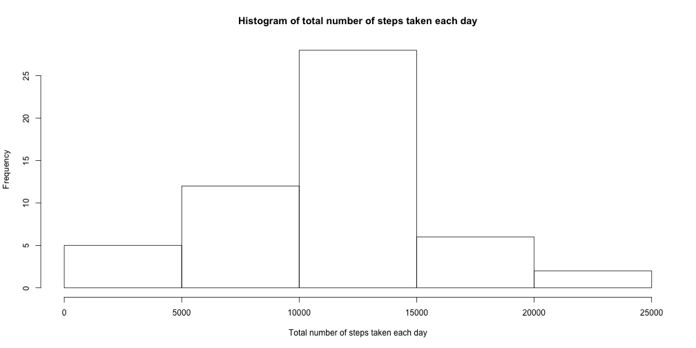

```r
df_mean_total_no_of_steps <- activity_df[complete.cases(activity_df), ]
hist(tapply(df_mean_total_no_of_steps$steps, df_mean_total_no_of_steps$date, sum, na.rm = T),
     xlab = "Total number of steps taken each day", ylab = "Frequency",
     main = "Histogram of total number of steps taken each day")
```

Calculating the mean and median total number of steps taken per day

```r
mean_total_per_day <- mean(tapply(df_mean_total_no_of_steps$steps, df_mean_total_no_of_steps$date, sum, na.rm = T), na.rm = T)
median_total_per_day <- median(tapply(df_mean_total_no_of_steps$steps, df_mean_total_no_of_steps$date, sum, na.rm = T), na.rm = T)
mean_total_per_day = as.numeric(mean_total_per_day)
```

The mean total number of steps taken per day is 1.0766189 × 10<sup>4</sup>.

The median total number of steps taken per day is 10765.

## What is the average daily activity pattern?

Time series plot of 5 minutes interval (x-axis) and the average number of steps taken, averaged across all days (y-axis)

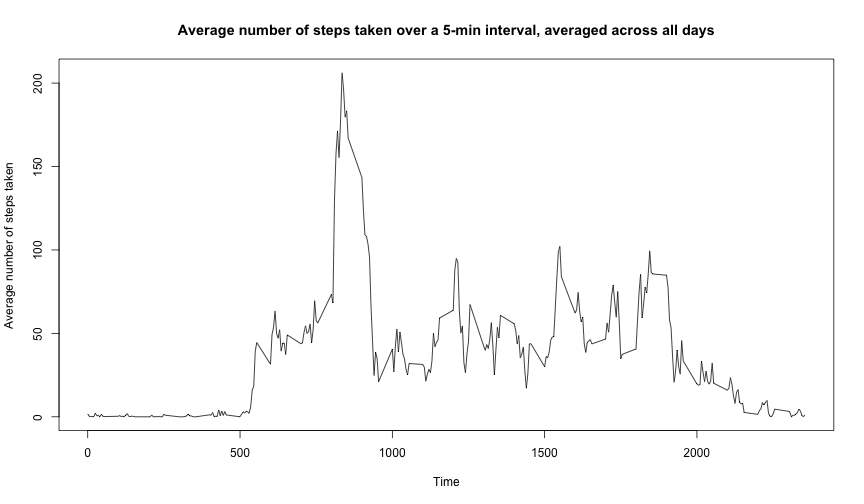

```r
plot(sort(unique(activity_df$HM)), tapply(activity_df$steps, activity_df$HM, mean, na.rm = T),
     xlab = "Time", ylab = "Average number of steps taken", type = "l",
     main = "Average number of steps taken over a 5-min interval, averaged across all days")
```

```r
avg_steps_by_5min <- tapply(activity_df$steps, activity_df$HM, mean, na.rm = T)
top_5min_int <- activity_df$HM[which(avg_steps_by_5min == max(avg_steps_by_5min))]
max_5min_steps <- avg_steps_by_5min[which(avg_steps_by_5min == max(avg_steps_by_5min))]
```

The 5 minute interval from 0835 contains the maximum number of steps (206.1698113).

## Imputing missing values

Calculating the total number of missing values in the dataset

```r
no_of_missing_values <- sum(is.na(activity_df))
```

The total number of missing values in the dataset is 2304.

To imput the missing values for each 5 minute interval, we will use the average steps taken over the 5 minute interval.

```r
activity_df_imputed <- activity_df
for (i in 1:dim(activity_df_imputed)[1]){
        if (is.na(activity_df$steps[i])){
                activity_df_imputed$steps[i] <- mean(activity_df$steps[activity_df$HM == activity_df$HM[i]], na.rm = T)
        }
}
```

Before Imputing Missing Values

```r
head(activity_df)
```

```
##   steps       date interval   HM
## 1    NA 2012-10-01        0 0000
## 2    NA 2012-10-01        5 0005
## 3    NA 2012-10-01       10 0010
## 4    NA 2012-10-01       15 0015
## 5    NA 2012-10-01       20 0020
## 6    NA 2012-10-01       25 0025
```

After Imputing Missing Values

```r
head(activity_df_imputed)
```

```
##       steps       date interval   HM
## 1 1.7169811 2012-10-01        0 0000
## 2 0.3396226 2012-10-01        5 0005
## 3 0.1320755 2012-10-01       10 0010
## 4 0.1509434 2012-10-01       15 0015
## 5 0.0754717 2012-10-01       20 0020
## 6 2.0943396 2012-10-01       25 0025
```

Histogram of total number of steps taken per day after imputing missing values

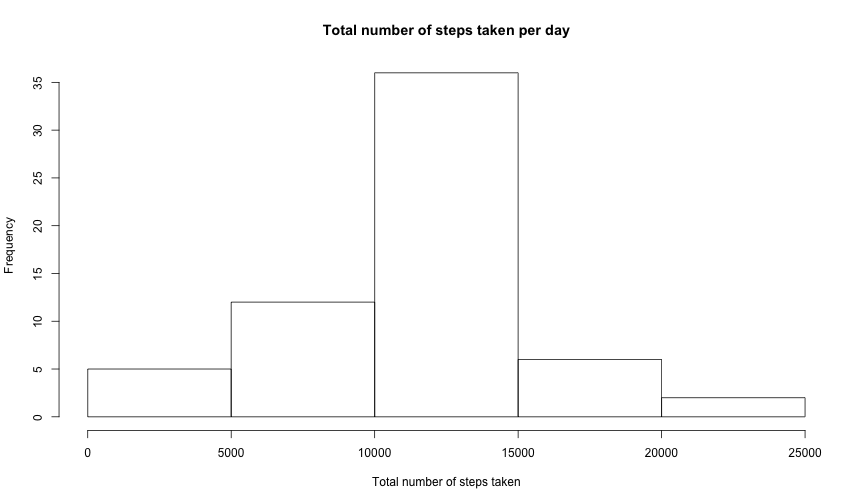

```r
hist(tapply(activity_df_imputed$steps, activity_df_imputed$date, sum),
     xlab = "Total number of steps taken", ylab = "Frequency",
     main = "Total number of steps taken per day")
```

```r
imputed_mean_no_of_steps <- mean(tapply(activity_df_imputed$steps, activity_df_imputed$date, sum, na.rm = T))
imputed_median_no_of_steps <- (tapply(activity_df_imputed$steps, activity_df_imputed$date, sum, na.rm = T))
```

The mean total number of steps taken per day after imputing the missing values is 1.0766189 × 10<sup>4</sup>.

## Are there differences in activity patterns between weekdays and weekends?

Creating a new factor variable to differentiate between weekdays and weekends

```r
for (i in 1:dim(activity_df_imputed)[1]){
        if (format(activity_df_imputed$date[i], "%a")  %in% c("Sat", "Sun")){
                activity_df_imputed$weekday[i] <- "Weekend"
        } else {
                activity_df_imputed$weekday[i] <- "Weekday"
        }
}
```

Creating a facet plot to see the differences in the activity patterns between weekdays and weekends

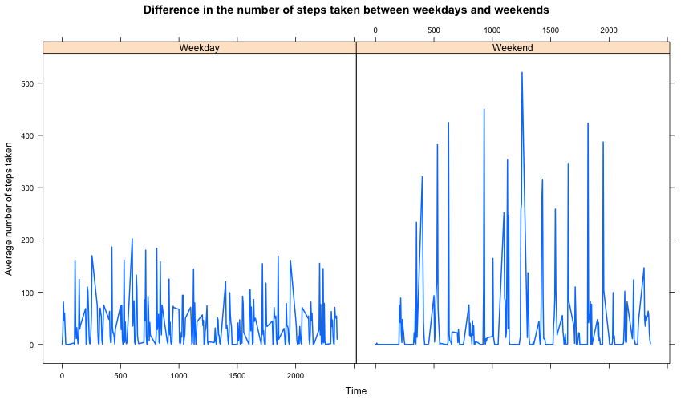

```r
activity_df_imputed$HM_weekday <- paste(activity_df_imputed$weekday, activity_df_imputed$HM, sep = "")

mean_steps_by_HM_weekend <- tapply(activity_df_imputed$steps, sort(activity_df_imputed$HM_weekday), mean)

df_mean_steps_by_HM_weekend <- data.frame(mean_steps_by_HM_weekend)
df_mean_steps_by_HM_weekend$weekday <- as.factor(substr(sort(unique(activity_df_imputed$HM_weekday)), 1, 7))
df_mean_steps_by_HM_weekend$HM <- substr(sort(unique(activity_df_imputed$HM_weekday)), 8, 11)

xyplot(mean_steps_by_HM_weekend ~ as.numeric(HM) | weekday,
       data = df_mean_steps_by_HM_weekend,
       type = "l", lwd = 2,
       xlab = "Time", ylab = "Average number of steps taken",
       main = "Difference in the number of steps taken between weekdays and weekends")
```